# Lab-5b Submission

Stat 133

Author

Gaston Sanchez

**General Instructions**

This is the second part (lab05b) which involves a shiny app that displays a histogram of waiting times from the `faithful` data (i.e. Old Faithful Geyser). This time, you’ll have to use functions from the `"ggplot2"` package to graph the histogram.

To be more specific, you need to create a basic shiny app, and submit the associated `app.R` file to bCourses, jointly with a screenshot of the app.

# 1 Histogram of Old Faithful waiting times

As you know, every time you open a new shiny app RStudio creates the default Old Faithful app. In particular, this app displays a histogram to visualize the distribution of waiting times, and lets you choose the number of bins with a slider widget (see screenshot below).

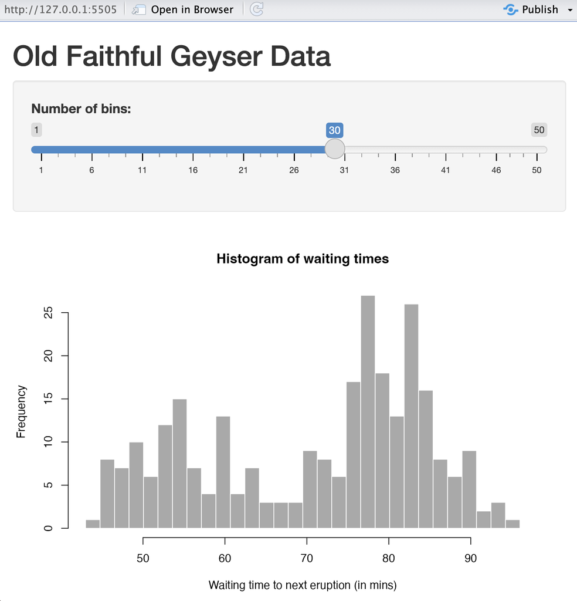

Figure 1: Default Old Faihtful shiny app

# 2 Histogram with `"ggplot2"` functions

Instead of using the `hist()` function to make the histogram, we are going to use functions from the **tidyverse** package `"ggplot2"`, which means we need to load `"tidyverse"`

```r
library(tidyverse)
```

To make a histogram of waiting times we need to use `ggplot()` and the layer `geom_histogram()`. The good news is that `geom_histogram()` comes with the `bins` argument which allows you to specify the number of bins to be used in the displayed distribution.

## 2.1 Example

Here’s some `ggplot` code to make a histogram of `waiting` times:

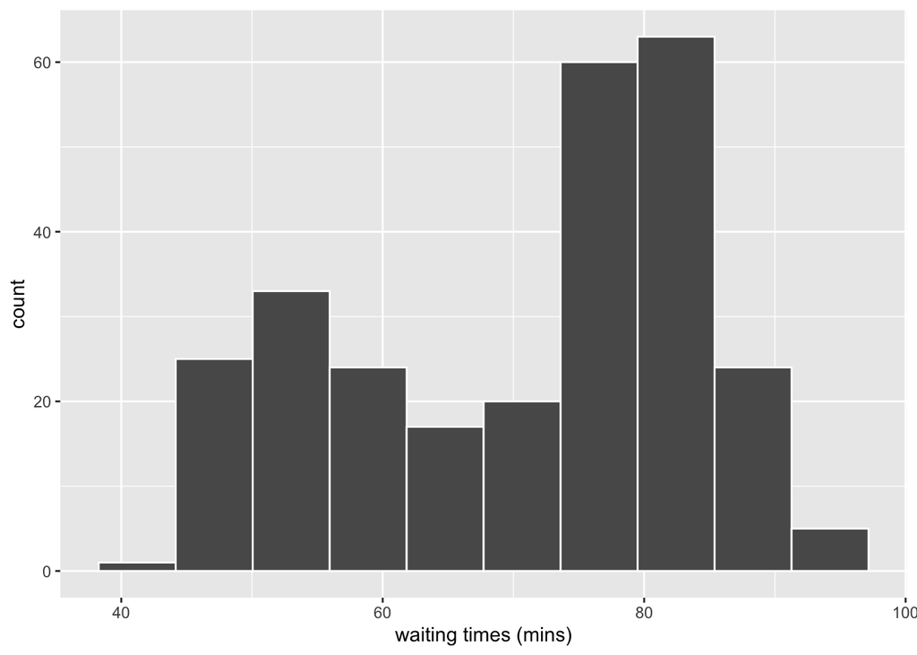

```r
ggplot(data = faithful, aes(x = waiting)) +
  geom_histogram(bins = 10, color = "white") +
  labs(x = "waiting times (mins)")
```

**Important**

How would you modify the preceding command in order to:

- `fill` the bars of the histogram with your favorite color
- include a meaningful `title` for the histogram
- customize the appearance of the graphic with one of the custom themes; e.g. `theme_minimal()`

# 3 Your Shiny App

Follow these steps to create your shiny app:

**Step 1)** In the menu bar, click the icon to open a new file, and select **Shiny Web App …**

[figure not shown]

Figure 2: Open a Shiny Web App

**Step 2)** Give a name to your app, and choose a directory location for it.

[figure not shown]

Figure 3: Specify a name and a directory location

**Step 3)** In the `app.R` file, add some *header* comments to provide a title, description, author, and date. And don’t forget to include `library(tidyverse)`

[figure not shown]

Figure 4: Add header comments, and load tidyverse

**Step 4)** Adapt the code of the app so that the displayed histogram is graphed with `ggplot()` and friends. To be more specific:

1. You don’t need to touch the code of the `ui`
2. What you need to modify is the code of the `server`
3. Delete the commands inside the `renderPlot({})` function, and replace them with the ggplot commands by adapting the code given in section **2.1 Example**
4. Recall that the number of bins is now an **input** element; therefore you need to refer to it as `input$bins`
5. Color the bars of the histogram with your favorite color; add a title; use one of the custom themes.
6. *Optional*: Feel free to customize your histogram with more changes (e.g. add more input widgets).

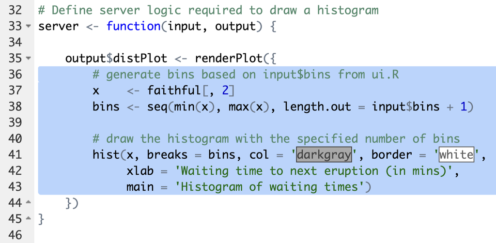

Figure 5: Delete the code inside renderPlot() and replace them with ggplot commands

**Step 5)** Run the app. Your adapted shiny app could look like this:

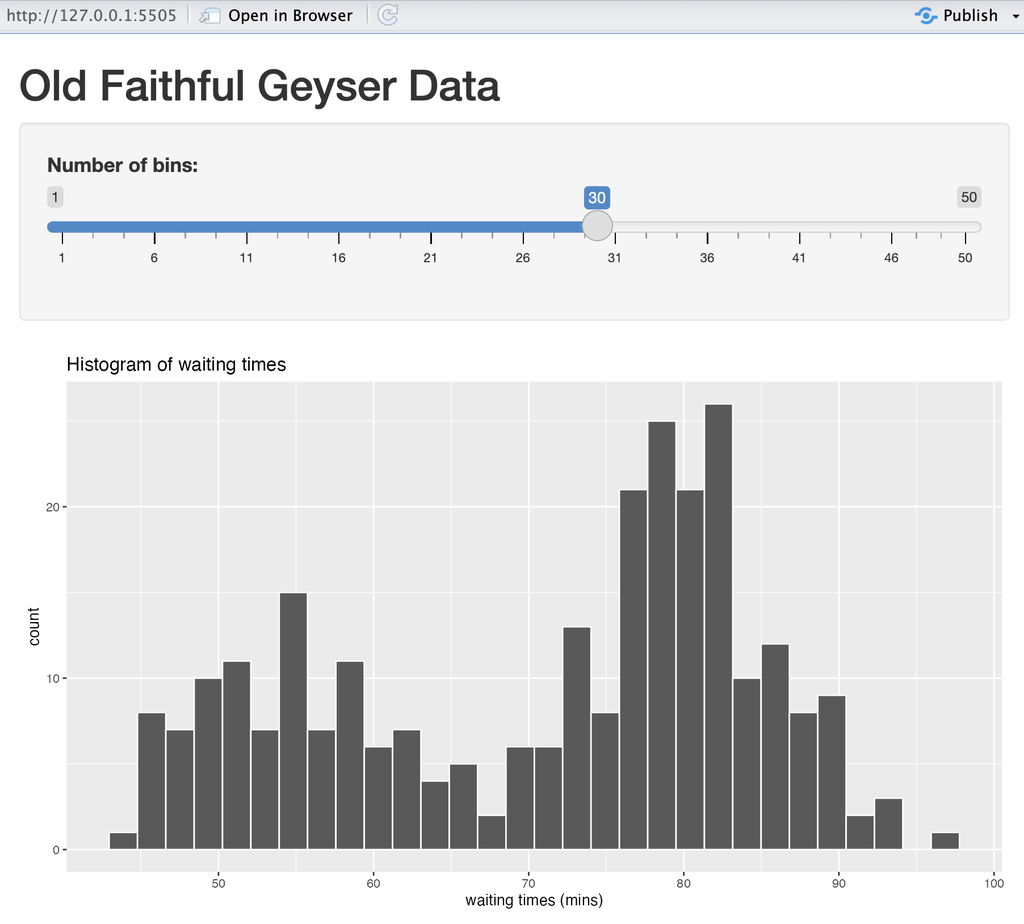

Figure 6: Shiny app with histogram via ggplot

**Step 6)** Take a screenshot of your shiny app, and submit your `app.R` file as well as the screenshot to bCourses (lab-05b submission).